# POLS0066 - Data Analysis

GNWL7

2024-01-02

# Affective Polarisation in the French multiparty system`

## Setup

The data comes from Sciences Po’s [Dataverse](https://data.sciencespo.fr/dataverse/donneesrecherche). Data from Waves 1-4 has been imported as csv’s, and stored in the /data folder. It has been aggregated and cleaned in `data_cleaning.R`.

### Adding Party Age

The analysis might involve party age:

Now let’s create a simple model regressing party identity strength on party age.

```
##
## Call:
## lm(formula = PID_strength ~ party_age, data = df1)
##
## Residuals:
##     Min      1Q  Median      3Q     Max
## -1.7859 -0.7524  0.2173  0.2456  1.2791
##
## Coefficients:
##               Estimate Std. Error t value Pr(>|t|)
## (Intercept)  2.7865209  0.0274174 101.633   <2e-16 ***
## party_age   -0.0006433  0.0008414  -0.765    0.445
## ---
## Signif. codes:  0 '***' 0.001 '**' 0.01 '*' 0.05 '.' 0.1 ' ' 1
##
## Residual standard error: 0.6875 on 1200 degrees of freedom
##   (8 observations deleted due to missingness)
## Multiple R-squared:  0.0004868,  Adjusted R-squared:  -0.0003461
## F-statistic: 0.5845 on 1 and 1200 DF,  p-value: 0.4447
```

This simple model yields no statistical significance.

### Adding Party Vote Share

In- and out-group evaluations will be weighted using vote shares so that larger parties count more. We use data for the first round of the 2022 Presidential election, from the French Ministry of the Interior (Ministère de l’Intérieur). Although this proxy has limitations, it has been used in previous studies and constitutes an improvement from unweighted evaluations.

In the calculations of in- and out-bloc sympathy, each party’s evaluation will be weighted by the ratio of votes gained by that party as a part of the bloc’s overall votes. See Reiljan & Ryan (2021, Appendix) for more details.

## Insight on the French Party System

We can run some exploratory data analysis to explore how supporters of the most prominent French parties feel about each other.

[output not shown]

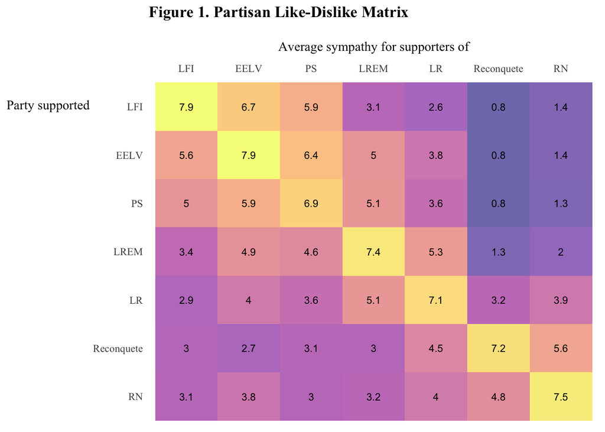

Let us confirm if these dynamics are similar when looking at party sympathy instead of supporters sympathy.

[output not shown]

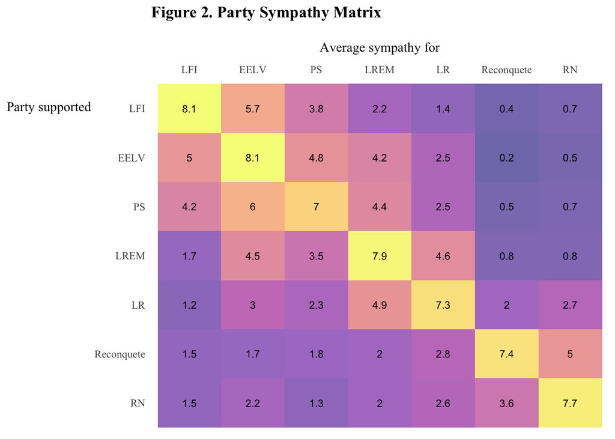

Similar results are displayed in Figure 2, with the main difference being that grades are slightly lower for out-parties than their supporters in general, and higher for in-parties than in-supporters.

Exploratory analysis of data from the 2022 French Election Study therefore corroborates Knapp’s analysis (2022). The tripolarisation of the party system in France follows a logical ideological pattern.

## Wave 4 Analysis - The Impact of Ideological Difference and Partisan Identity on Affective Polarisation

We can now move on to the testing of our hypotheses.

The fourth wave of the 2022 French Election Study, carried out after the Presidential election from April 28 to June 2, 2022, takes up the entirety of module 6 (2021-2026) of the CSES (Comparative study of electoral systems) international comparison project.

### Adding Ideological distance

To include ideological distance in models, both the objective and subjective ideological positions of parties can be computed. Objective ideological position is the respondents’ average rating of the party’s left-right position. Subjective ideological position is each respondent’s rating of the party’s left-right position.

## Affective polarisation and Ideological Distance for Three Blocs

First supporters within the Left-plus-Greens bloc:

```
##
## Call:
## lm(formula = affect_polarisation_centre_right ~ PID_strength +
##     socioeco + in_group_sympathy + environment + +immigration +
##     interest_politics, data = left_bloc_df)
##
## Residuals:
##     Min      1Q  Median      3Q     Max
## -7.2875 -1.0772  0.0337  1.0462  5.2730
##
## Coefficients:
##                   Estimate Std. Error t value Pr(>|t|)
## (Intercept)        1.58785    0.76391   2.079  0.03835 *
## PID_strength       0.91820    0.16068   5.714 2.29e-08 ***
## socioeco          -0.59520    0.18629  -3.195  0.00152 **
## in_group_sympathy  1.46251    0.16097   9.086  < 2e-16 ***
## environment1       0.05923    0.26443   0.224  0.82287
## immigration       -0.29304    0.14226  -2.060  0.04012 *
## interest_politics  0.13415    0.12481   1.075  0.28317
## ---
## Signif. codes:  0 '***' 0.001 '**' 0.01 '*' 0.05 '.' 0.1 ' ' 1
##
## Residual standard error: 1.819 on 365 degrees of freedom
##   (86 observations deleted due to missingness)
## Multiple R-squared:  0.4345, Adjusted R-squared:  0.4252
## F-statistic: 46.74 on 6 and 365 DF,  p-value: < 2.2e-16
```

```
##
## Call:
## lm(formula = affect_polarisation_far_right ~ PID_strength + socioeco +
##     in_group_sympathy + environment + +immigration + interest_politics,
##     data = left_bloc_df)
##
## Residuals:
##     Min      1Q  Median      3Q     Max
## -6.3857 -0.9953  0.1067  1.0000  6.1306
##
## Coefficients:
##                   Estimate Std. Error t value Pr(>|t|)
## (Intercept)         3.3929     0.7508   4.519 8.40e-06 ***
## PID_strength        1.1343     0.1583   7.167 4.26e-12 ***
## socioeco           -0.1600     0.1835  -0.872    0.384
## in_group_sympathy   1.0358     0.1579   6.559 1.86e-10 ***
## environment1        0.1857     0.2605   0.713    0.476
## immigration        -0.8060     0.1399  -5.763 1.76e-08 ***
## interest_politics   0.1855     0.1229   1.509    0.132
## ---
## Signif. codes:  0 '***' 0.001 '**' 0.01 '*' 0.05 '.' 0.1 ' ' 1
##
## Residual standard error: 1.792 on 366 degrees of freedom
##   (85 observations deleted due to missingness)
## Multiple R-squared:  0.4415, Adjusted R-squared:  0.4323
## F-statistic: 48.22 on 6 and 366 DF,  p-value: < 2.2e-16
```

```
##
## Call:
## lm(formula = affect_polarisation_left ~ PID_strength + socioeco +
##     in_group_sympathy + environment + +immigration + interest_politics,
##     data = far_right_bloc_df)
##
## Residuals:
##     Min      1Q  Median      3Q     Max
## -6.9792 -1.2405 -0.0413  1.3957  4.3021
##
## Coefficients:
##                   Estimate Std. Error t value Pr(>|t|)
## (Intercept)       -4.01416    1.07401  -3.738 0.000275 ***
## PID_strength       1.62721    0.23607   6.893 1.99e-10 ***
## socioeco           0.39252    0.27615   1.421 0.157542
## in_group_sympathy  0.81251    0.17824   4.559 1.15e-05 ***
## environment1      -0.03795    0.33755  -0.112 0.910656
## immigration        0.66786    0.31078   2.149 0.033448 *
## interest_politics  0.17609    0.21953   0.802 0.423896
## ---
## Signif. codes:  0 '***' 0.001 '**' 0.01 '*' 0.05 '.' 0.1 ' ' 1
##
## Residual standard error: 1.918 on 133 degrees of freedom
##   (37 observations deleted due to missingness)
## Multiple R-squared:  0.5902, Adjusted R-squared:  0.5717
## F-statistic: 31.93 on 6 and 133 DF,  p-value: < 2.2e-16
```

```
##
## Call:
## lm(formula = affect_polarisation_center_right ~ PID_strength +
##     socioeco + in_group_sympathy + environment + +immigration +
##     interest_politics, data = far_right_bloc_df)
##
## Residuals:
##     Min      1Q  Median      3Q     Max
## -7.1428 -1.1958 -0.1406  1.4408  5.1576
##
## Coefficients:
##                   Estimate Std. Error t value Pr(>|t|)
## (Intercept)       -4.16394    1.23630  -3.368 0.000987 ***
## PID_strength       1.75767    0.26722   6.578 9.66e-10 ***
## socioeco          -0.12889    0.31576  -0.408 0.683771
## in_group_sympathy  0.78438    0.20494   3.827 0.000197 ***
## environment1       0.01489    0.38633   0.039 0.969318
## immigration        0.87421    0.35593   2.456 0.015314 *
## interest_politics  0.09108    0.25156   0.362 0.717868
## ---
## Signif. codes:  0 '***' 0.001 '**' 0.01 '*' 0.05 '.' 0.1 ' ' 1
##
## Residual standard error: 2.211 on 135 degrees of freedom
##   (35 observations deleted due to missingness)
## Multiple R-squared:  0.5348, Adjusted R-squared:  0.5141
## F-statistic: 25.87 on 6 and 135 DF,  p-value: < 2.2e-16
```

```
##
## Call:
## lm(formula = affect_polarisation_left ~ PID_strength + socioeco +
##     in_group_sympathy + environment + +immigration + interest_politics,
##     data = centre_right_bloc_df)
##
## Residuals:
##     Min      1Q  Median      3Q     Max
## -9.7044 -0.9945  0.1484  1.2878  5.0289
##
## Coefficients:
##                   Estimate Std. Error t value Pr(>|t|)
## (Intercept)        0.41376    0.81503   0.508   0.6120
## PID_strength       1.55391    0.17177   9.047   <2e-16 ***
## socioeco           0.06445    0.19218   0.335   0.7376
## in_group_sympathy  0.17445    0.09696   1.799   0.0728 .
## environment1       0.13688    0.24953   0.549   0.5837
## immigration        0.36363    0.15404   2.361   0.0188 *
## interest_politics  0.15221    0.14269   1.067   0.2868
## ---
## Signif. codes:  0 '***' 0.001 '**' 0.01 '*' 0.05 '.' 0.1 ' ' 1
##
## Residual standard error: 1.975 on 356 degrees of freedom
##   (89 observations deleted due to missingness)
## Multiple R-squared:  0.2325, Adjusted R-squared:  0.2195
## F-statistic: 17.97 on 6 and 356 DF,  p-value: < 2.2e-16
```

```
##
## Call:
## lm(formula = affect_polarisation_far_right ~ PID_strength + socioeco +
##     in_group_sympathy + environment + +immigration + interest_politics,
##     data = centre_right_bloc_df)
##
## Residuals:
##     Min      1Q  Median      3Q     Max
## -9.6049 -0.9128  0.2689  1.2693  7.3118
##
## Coefficients:
##                   Estimate Std. Error t value Pr(>|t|)
## (Intercept)        1.64475    0.82409   1.996 0.046704 *
## PID_strength       1.22333    0.17113   7.149 4.91e-12 ***
## socioeco          -0.03240    0.19448  -0.167 0.867783
## in_group_sympathy  0.78201    0.09801   7.979 1.99e-14 ***
## environment1       0.42886    0.25262   1.698 0.090436 .
## immigration       -0.51569    0.15515  -3.324 0.000979 ***
## interest_politics  0.01843    0.14332   0.129 0.897767
## ---
## Signif. codes:  0 '***' 0.001 '**' 0.01 '*' 0.05 '.' 0.1 ' ' 1
##
## Residual standard error: 2 on 360 degrees of freedom
##   (85 observations deleted due to missingness)
## Multiple R-squared:  0.3521, Adjusted R-squared:  0.3413
## F-statistic:  32.6 on 6 and 360 DF,  p-value: < 2.2e-16
```